# Exercises STAT340 - ANOVA - part II

**Colloquium exercises:** You are encouraged to work together in groups on the exercises. Sharing problems and solutions is often a much quicker way to learn, especially for problems of a more practical nature.

Here are some packages and data you need to use in these exercises. So you should run these commands before you start the exercises.

```r
library(mixlm)
library(car)
library(effects)
library(BIAS.data)
data(NSRdata)
data(Barley)
data(birth)
```

# 1 Ex-2: Yield of barley

In `Barley` there are results from an experiment where the response is yield of barley pr 1000 square meter, and the factors varieties of barley, soil types, types of fertilizers. In addition was the experiment done in two different geographical areas (sites).

- Assume a two factor model including the main effects of `Variety` and `Soil` and their interaction. State the model and explain all parameters under a sum-to-zero parametrization.

**Solution**

The model can be written as:
$$y_{ijk} =
\mu + \alpha_i + \beta_j + (\alpha\beta)_{ij} + \epsilon_{ijk}$$
where, $\epsilon \sim N(0, \sigma^2)$

The parametrization restrictions for “sum-to-zero”” are:
$$\begin{eqnarray}
\sum_i{\alpha_i} = 0, & \sum_j{\beta_j} = 0, &
\sum_{i}{(\alpha\beta)_{ij}} = 0 \text{ and }
\sum_{j}{(\alpha\beta)_{ij}} = 0
\end{eqnarray}$$

- Fit the model in R and estimate all parameters

**Solution**

```r
# either
mod1 <- mixlm::lm(Yield ~ Variety * Soil, data = Barley, contrasts="contr.sum")
# or
mod1 <- stats::lm(Yield ~ Variety * Soil, data = Barley, contrasts = list(x = contr.sum))
summod1 <- summary(mod1, cor=FALSE)
print(summod1)
```

```
##
## Call:
## stats::lm(formula = Yield ~ Variety * Soil, data = Barley, contrasts = list(x = contr.sum))
##
## Residuals:
##     Min      1Q  Median      3Q     Max
## -88.469 -44.322   5.009  35.219 106.913
##
## Coefficients:
##                    Estimate Std. Error t value Pr(>|t|)
## (Intercept)          385.17      19.30  19.955   <2e-16 ***
## VarietyC2             56.96      27.30   2.087   0.0462 *
## SoilSand             -35.71      27.30  -1.308   0.2015
## VarietyC2:SoilSand   -73.62      38.60  -1.907   0.0668 .
## ---
## Signif. codes:  0 '***' 0.001 '**' 0.01 '*' 0.05 '.' 0.1 ' ' 1
##
## Residual standard error: 54.6 on 28 degrees of freedom
## Multiple R-squared:  0.4022, Adjusted R-squared:  0.3382
## F-statistic:  6.28 on 3 and 28 DF,  p-value: 0.002142
```

```r
anova(mod1)
```

```
## Analysis of Variance Table
##
## Response: Yield
##              Df Sum Sq Mean Sq F value    Pr(>F)
## Variety       1   3247    3247  1.0893 0.3055521
## Soil          1  42071   42071 14.1146 0.0008031 ***
## Variety:Soil  1  10841   10841  3.6370 0.0668166 .
## Residuals    28  83459    2981
## ---
## Signif. codes:  0 '***' 0.001 '**' 0.01 '*' 0.05 '.' 0.1 ' ' 1
```

From the model summaries we find the estimated parameters to be:

1. The estimated overall mean yield: $\hat{\mu}=$ 385.1745876
2. The estimated effects of Variety 1 and 2: $\hat{\alpha}_1=$ 56.9574066, $\hat{\alpha}_2 = -\hat{\alpha}_1 =$ -56.9574066
3. The estimated effects of Soil 1 and 2: $\hat{\beta}_1=$ -35.7065893, $\hat{\beta}_2 = -\hat{\beta}_1 =$ 35.7065893
4. The estimated interaction effects of Variety and Soil: $\hat{\alpha\beta}_{11}=$ -73.62293, $\hat{\alpha\beta}_{12}=-\hat{\alpha\beta}_{11}=$ 73.62293, $\hat{\alpha\beta}_{21}=-\hat{\alpha\beta}_{11}=$ 73.62293, $\hat{\alpha\beta}_{22}=-\hat{\alpha\beta}_{21}=-\hat{\alpha\beta}_{12}=$ -73.62293
5. The estimated within `variety:Soil` levels unexplained variability: $\hat{\sigma}^2=MSE=$ 2980.67
- Make an interaction plot and try to conclude about the presence of interaction from the plot. How would you explain interaction effect in this example for a person with experience in agriculture, but minimal statistical experience?

**Solution**

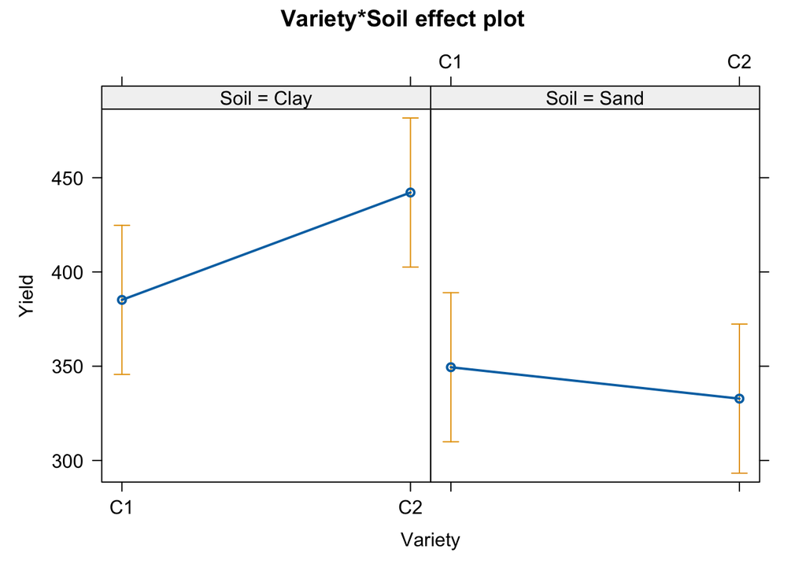

```r
plot(allEffects(mod1,confidence.level = .95))
```

From the plot, it seems that a farmer can expect an increase in yield when using Variety 2 instead of Variety 1 for Soil = Clay, but vice versa for Soil = Sand. If this is so, there is a so-called interaction effect of Variety and Soil on yield.

- Perform a hypothesis test for the interaction effect. Conclusion?

**Solution**

```r
anova(mod1)
```

```
## Analysis of Variance Table
##
## Response: Yield
##              Df Sum Sq Mean Sq F value    Pr(>F)
## Variety       1   3247    3247  1.0893 0.3055521
## Soil          1  42071   42071 14.1146 0.0008031 ***
## Variety:Soil  1  10841   10841  3.6370 0.0668166 .
## Residuals    28  83459    2981
## ---
## Signif. codes:  0 '***' 0.001 '**' 0.01 '*' 0.05 '.' 0.1 ' ' 1
```

The interaction between `Soil` and `Variety` is insignificant at 5% testlevel (p-value > 0.05). This result indicates that the slight non-parallel tendency of the lines in the interaction plot may be due to random errors. More data would be needed to verify any interaction effect.

- Fit a four factor model with Variety, Soil, Fetilizer and Site as factors and with all possible 2-factor, 3-factor and 4-factor interactions. Are there any higher order significant effects? Compare the R-squared and the adjusted R-squared values. What can you conclude from these?

**Solution**

```r
mod2 <- stats::lm(Yield ~ Variety * Soil * Fertilizer * Site, data = Barley)
anova(mod2)
```

```
## Analysis of Variance Table
##
## Response: Yield
##                              Df Sum Sq Mean Sq F value    Pr(>F)
## Variety                       1   3247    3247  4.9373 0.0410530 *
## Soil                          1  42071   42071 63.9750  5.56e-07 ***
## Fertilizer                    1   9846    9846 14.9725 0.0013585 **
## Site                          1   1073    1073  1.6323 0.2196068
## Variety:Soil                  1  10841   10841 16.4848 0.0009095 ***
## Variety:Fertilizer            1   6398    6398  9.7296 0.0066081 **
## Soil:Fertilizer               1  46396   46396 70.5525  2.93e-07 ***
## Variety:Site                  1   1073    1073  1.6320 0.2196548
## Soil:Site                     1   1405    1405  2.1361 0.1632290
## Fertilizer:Site               1    191     191  0.2901 0.5975463
## Variety:Soil:Fertilizer       1   3639    3639  5.5341 0.0317798 *
## Variety:Soil:Site             1   2671    2671  4.0612 0.0609974 .
## Variety:Fertilizer:Site       1      4       4  0.0063 0.9378245
## Soil:Fertilizer:Site          1    154     154  0.2337 0.6353262
## Variety:Soil:Fertilizer:Site  1     86      86  0.1308 0.7223569
## Residuals                    16  10522     658
## ---
## Signif. codes:  0 '***' 0.001 '**' 0.01 '*' 0.05 '.' 0.1 ' ' 1
```

```r
summary(mod2)
```

```
##
## Call:
## stats::lm(formula = Yield ~ Variety * Soil * Fertilizer * Site,
##     data = Barley)
##
## Residuals:
##    Min     1Q Median     3Q    Max
## -39.10 -11.44   0.00  11.44  39.10
##
## Coefficients:
##                                               Estimate Std. Error t value
## (Intercept)                                   343.5266    18.1331  18.945
## VarietyC2                                      36.6158    25.6440   1.428
## SoilSand                                       12.9947    25.6440   0.507
## FertilizerFert2                               111.4824    25.6440   4.347
## SiteSite2                                     -34.8928    25.6440  -1.361
## VarietyC2:SoilSand                             -0.9803    36.2661  -0.027
## VarietyC2:FertilizerFert2                     -19.0243    36.2661  -0.525
## SoilSand:FertilizerFert2                     -107.4431    36.2661  -2.963
## VarietyC2:SiteSite2                            54.5868    36.2661   1.505
## SoilSand:SiteSite2                             12.2494    36.2661   0.338
## FertilizerFert2:SiteSite2                      13.4130    36.2661   0.370
## VarietyC2:SoilSand:FertilizerFert2            -72.2000    51.2880  -1.408
## VarietyC2:SoilSand:SiteSite2                  -59.9703    51.2880  -1.169
## VarietyC2:FertilizerFert2:SiteSite2            10.2413    51.2880   0.200
## SoilSand:FertilizerFert2:SiteSite2             -4.4178    51.2880  -0.086
## VarietyC2:SoilSand:FertilizerFert2:SiteSite2  -26.2301    72.5322  -0.362
##                                              Pr(>|t|)
## (Intercept)                                   2.2e-12 ***
## VarietyC2                                    0.172563
## SoilSand                                     0.619252
## FertilizerFert2                              0.000499 ***
## SiteSite2                                    0.192481
## VarietyC2:SoilSand                           0.978770
## VarietyC2:FertilizerFert2                    0.607070
## SoilSand:FertilizerFert2                     0.009166 **
## VarietyC2:SiteSite2                          0.151764
## SoilSand:SiteSite2                           0.739933
## FertilizerFert2:SiteSite2                    0.716344
## VarietyC2:SoilSand:FertilizerFert2           0.178341
## VarietyC2:SoilSand:SiteSite2                 0.259415
## VarietyC2:FertilizerFert2:SiteSite2          0.844244
## SoilSand:FertilizerFert2:SiteSite2           0.932427
## VarietyC2:SoilSand:FertilizerFert2:SiteSite2 0.722357
## ---
## Signif. codes:  0 '***' 0.001 '**' 0.01 '*' 0.05 '.' 0.1 ' ' 1
##
## Residual standard error: 25.64 on 16 degrees of freedom
## Multiple R-squared:  0.9246, Adjusted R-squared:  0.854
## F-statistic: 13.09 on 15 and 16 DF,  p-value: 2.946e-06
```

There is only one main effect and one interaction effect significant at 5% levels, namely the `Fertilizer` main effect and the `Soil:Fertilizer` interaction. However, the least squares estimator is prone to inflated variance estimates and difficulties in finding significance when the number of variables `k` rises compared to the number of observations `N` and if variables are highly correlated. Too many variables to estimate from a limited number of observations leaves few degrees of freedom to SSE, and tests with low power. Lack of significance may be an over-fitting problem. By removing some of the least significant variables, the problem is reduced, and a reduced model with significant effects may be identified.

The large difference between $R^2$ and $R_{adj}^2$ is also an indication of an over-fitted model.

- Try to reduce the model by excluding the least significant higher order interactions first, one at a time, in a backward elimination procedure using the ‘backward’ function from the `mixlm` package. Use the ‘hierarchy = TRUE’ argument to ensure that the so-called marginality principle is followed. What is the final reduced model?

**Solution**

```r
mod2.red <- backward(mod2, alpha = 0.05, full = TRUE, hierarchy = TRUE)
```

```
## Backward elimination, alpha-to-remove: 0.05
##
## Full model: Yield ~ Variety + Soil + Fertilizer + Site + Variety:Soil + Variety:Fertilizer +
##     Soil:Fertilizer + Variety:Site + Soil:Site + Fertilizer:Site +
##     Variety:Soil:Fertilizer + Variety:Soil:Site + Variety:Fertilizer:Site +
##     Soil:Fertilizer:Site + Variety:Soil:Fertilizer:Site
##
## --= Step 1 =--
## Single term deletions
##
## Model:
## Yield ~ Variety * Soil * Fertilizer * Site
##                              Df Sum of Sq   RSS    AIC F value Pr(>F)
## <none>                                    10522 217.46
## Variety:Soil:Fertilizer:Site  1    86.002 10608 215.72  0.1308 0.7224
##
##
## --= Step 2 =--
## Single term deletions
##
## Model:
## Yield ~ Variety + Soil + Fertilizer + Site + Variety:Soil + Variety:Fertilizer +
##     Soil:Fertilizer + Variety:Site + Soil:Site + Fertilizer:Site +
##     Variety:Soil:Fertilizer + Variety:Soil:Site + Variety:Fertilizer:Site +
##     Soil:Fertilizer:Site
##                         Df Sum of Sq   RSS    AIC F value  Pr(>F)
## <none>                               10608 215.72
## Variety:Soil:Fertilizer  1    3639.3 14247 223.15  5.8323 0.02728 *
## Variety:Soil:Site        1    2670.7 13279 220.90  4.2801 0.05412 .
## Variety:Fertilizer:Site  1       4.1 10612 213.73  0.0066 0.93612
## Soil:Fertilizer:Site     1     153.7 10762 214.18  0.2463 0.62604
## ---
## Signif. codes:  0 '***' 0.001 '**' 0.01 '*' 0.05 '.' 0.1 ' ' 1
##
##
## --= Step 3 =--
## Single term deletions
##
## Model:
## Yield ~ Variety + Soil + Fertilizer + Site + Variety:Soil + Variety:Fertilizer +
```

[output cut: 25 more lines]

```
##
##
## --= Step 5 =--
## Single term deletions
##
## Model:
## Yield ~ Variety + Soil + Fertilizer + Site + Variety:Soil + Variety:Fertilizer +
##     Soil:Fertilizer + Variety:Site + Soil:Site + Variety:Soil:Fertilizer +
##     Variety:Soil:Site
##                         Df Sum of Sq   RSS    AIC F value  Pr(>F)
## <none>                               10956 210.75
## Variety:Soil:Fertilizer  1    3639.3 14596 217.93  6.6432 0.01798 *
## Variety:Soil:Site        1    2670.7 13627 215.73  4.8752 0.03909 *
## ---
## Signif. codes:  0 '***' 0.001 '**' 0.01 '*' 0.05 '.' 0.1 ' ' 1
```

```r
anova(mod2.red)
```

```
## Analysis of Variance Table
##
## Response: Yield
##                         Df Sum Sq Mean Sq F value    Pr(>F)
## Variety                  1   3247    3247  5.9269 0.0244049 *
## Soil                     1  42071   42071 76.7965 2.773e-08 ***
## Fertilizer               1   9846    9846 17.9732 0.0004019 ***
## Site                     1   1073    1073  1.9595 0.1768893
## Variety:Soil             1  10841   10841 19.7886 0.0002467 ***
## Variety:Fertilizer       1   6398    6398 11.6796 0.0027287 **
## Soil:Fertilizer          1  46396   46396 84.6922 1.255e-08 ***
## Variety:Site             1   1073    1073  1.9591 0.1769344
## Soil:Site                1   1405    1405  2.5642 0.1249852
## Variety:Soil:Fertilizer  1   3639    3639  6.6432 0.0179818 *
## Variety:Soil:Site        1   2671    2671  4.8752 0.0390875 *
## Residuals               20  10956     548
## ---
## Signif. codes:  0 '***' 0.001 '**' 0.01 '*' 0.05 '.' 0.1 ' ' 1
```

The final reduced model is a model with all four main effects, three of which are now significant, five 2-order interactions (three significant), and two significant 3-order interactions. The 4-order interaction is removed. The marginality principle says that we should keep all main effects and interactions that are part of higher order significant interaction(s) in the model. This is a good principle for practical data analysis.

- Perform a model check of the reduced model using residual analysis.

**Solution**

The `backward` function has fitted the reduced model:

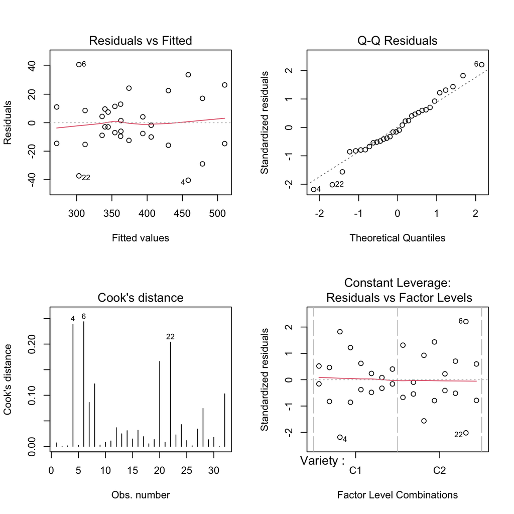

```r
par(mfrow = c(2,2))
plot(mod2.red, which = c(1,2,4,5))
```

The residual plots give no evidence of any problems with the model assumptions.

- You can make the third order interaction effects plot between `Variety`,`Site` and `Soil` like this:

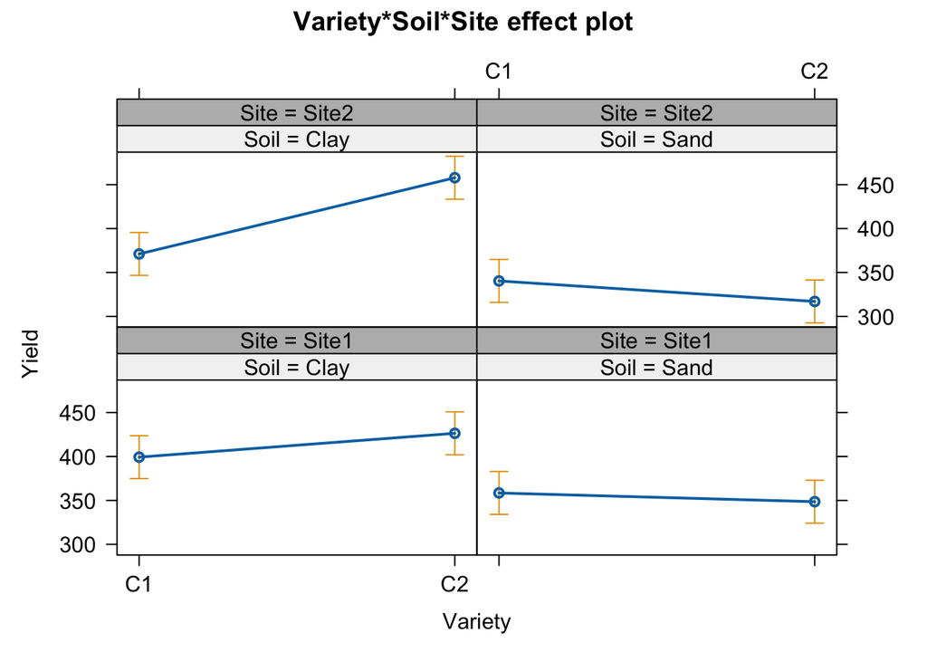

```r
eff <- allEffects(mod2.red, confidence.level = .95)
plot(eff[2])
```

Try to explain the plot. Why do you think the interaction between `Variety`,`Site` and `Soil` was significant?

**Solution**

The interaction effect is significant because the lines are not parallel. The effect of Soil on Yield is different for the two Varieties and the effect of Soil on Yield for one Variety may depend on Site. This is a three-way interaction effect.

# 2 Ex-2: Indicator variable (ANCOVA model)

This exercise is a follow up on the exercise from week 3 on multiple regression using the `mtcars` data set.

- The `am` variable is really an indicator variable for transmission system of the cars (The variable is coded as 0=automatic, 1=manual). Fit a multiple linear model with “cyl”, “wt”, “am” and the interaction between “wt” and “am” and report the summary of the model with parameter estimates and tests.

NOTE: Make sure the `am` is treated as a categorical variable in the model by writing `factor(am)` in the model formula in the linear model function. Use the default “sum to zero” parametrization when you fit the model.

**Solution**

```r
cars <- lm(mpg ~ cyl + wt * factor(am), data=mtcars, contrasts="contr.sum")
summary(cars)
```

```
##
## Call:
## lm(formula = mpg ~ cyl + wt * factor(am), data = mtcars, contrasts = "contr.sum")
##
## Residuals:
##     Min      1Q  Median      3Q     Max
## -3.4621 -1.4913 -0.7879  1.3959  5.3499
##
## Coefficients:
##                  Estimate Std. Error t value Pr(>|t|)
## (Intercept)       40.2523     1.9170  20.997  < 2e-16 ***
## cyl               -1.1814     0.3803  -3.106  0.00442 **
## wt                -4.4676     0.8943  -4.996 3.08e-05 ***
## factor(am)(0)     -5.9693     1.9227  -3.105  0.00444 **
## wt:factor(am)(0)   2.0987     0.6558   3.200  0.00350 **
## ---
## Signif. codes:  0 '***' 0.001 '**' 0.01 '*' 0.05 '.' 0.1 ' ' 1
##
## s: 2.265 on 27 degrees of freedom
## Multiple R-squared: 0.877,
## Adjusted R-squared: 0.8588
## F-statistic: 48.13 on 4 and 27 DF,  p-value: 6.643e-12
```

- Write up the assumed model which has been run here. Also write up the estimated models for automatic and manual transmission, respectively.

**Solution**

The model is:

$$y = \beta_0 + \beta_1 x_1 + \beta_2 x_2
+ \beta_3 x_3 + \beta_4 x_2\cdot x_3 + \epsilon$$

where $y$=`mpg`, $x_1$=`cyl`, $x_2$=`wt`, $x_3$=`am` and $\epsilon \sim N(0, \sigma^2)$.

For automatic transmission (`am`=$x_3$=1) we have the estimated model:
$$\begin{split}
\hat{y} &= 40.2523 - 1.1814x_1 - 4.4676x_2 - 5.9693 + 2.0987x_2\\
&=34.283 - 1.1814x_1 - 2.3689x_2
\end{split}$$

For manual transmission (`am`=$x_3$=-1) we have
$$\begin{split}
\hat{y} &= 40.2523 - 1.1814x_1 - 4.4676x_2 + 5.9693 - 2.0987x_2\\
&= 46.2216 - 1.1814x_1 - 6.5663x_2
\end{split}$$

We observe that the negative effect of weight on mileage is larger for manual transmission than for automatic.